# Lab8 Assignment

Dr.Purna Gamage

3/14/2022

```r
library(ISLR)
library(MASS)
library(tidyverse)
library(caret)
```

```r
library(mvtnorm)
library(plotly)
```

### 1. ROC Curves

We are going to implement our own ROC curve calculation.

1. Let’s reuse the model and data from last week.

```r
data(Smarket)
logistic_model=glm(Direction~Lag1+Lag2+Lag3+Lag4+Lag5, data=Weekly, family=binomial)
summary(logistic_model)
```

```
##
## Call:
## glm(formula = Direction ~ Lag1 + Lag2 + Lag3 + Lag4 + Lag5, family = binomial,
##     data = Weekly)
##
## Deviance Residuals:
##     Min       1Q   Median       3Q      Max
## -1.7297  -1.2574   0.9939   1.0868   1.4671
##
## Coefficients:
##             Estimate Std. Error z value Pr(>|z|)
## (Intercept)  0.23029    0.06203   3.712 0.000205 ***
## Lag1        -0.04010    0.02635  -1.522 0.128125
## Lag2         0.06015    0.02674   2.249 0.024503 *
## Lag3        -0.01508    0.02664  -0.566 0.571381
## Lag4        -0.02677    0.02643  -1.013 0.311082
## Lag5        -0.01349    0.02636  -0.512 0.608894
## ---
## Signif. codes:  0 '***' 0.001 '**' 0.01 '*' 0.05 '.' 0.1 ' ' 1
##
## (Dispersion parameter for binomial family taken to be 1)
##
##     Null deviance: 1496.2  on 1088  degrees of freedom
## Residual deviance: 1486.7  on 1083  degrees of freedom
## AIC: 1498.7
##
## Number of Fisher Scoring iterations: 4
```

```r
predict(logistic_model, type="response")[1:10]
```

```
##         1         2         3         4         5         6         7         8
## 0.5997942 0.5926544 0.5783581 0.4738901 0.6102069 0.5610662 0.5710399 0.5077955
##         9        10
## 0.5638349 0.5476513
```

```r
Smarket$Direction[1:10]
```

```
##  [1] Up   Up   Down Up   Up   Up   Down Up   Up   Up
## Levels: Down Up
```

Create a DataFrame for evaluation data where you have a column corresponding to the “true” labels and a column corresponding to the predicted probabilities.

2. Create a function called confusion_matrix() that takes in a DataFrame (like the above one) as well as a probability threshold, and returns the corresponding confusion matrix. (hint: the function table() is helpful here)
3. Simplify your previous function by having it return only the True Positive Rate and False Positive Rate elements of the confusion matrix.
4. For a range of probability thresholds from 0.0 to 1.0, evaluate your function from step 3 and collect the corresponding True Positive Rates and False Positive Rates.
5. Make a plot of TPR vs FPR (FPR on x-axis).

### 2. LDA & QDA

Below is a simulated dataset with 2dimension and 3 classes.

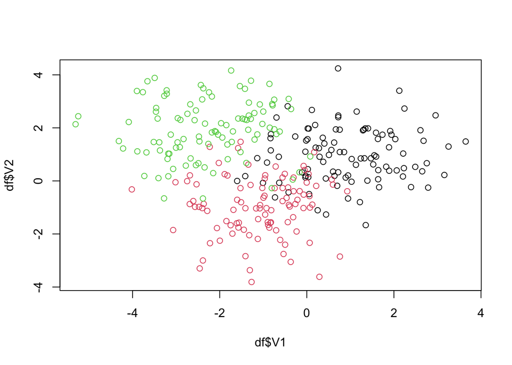

```r
Sigma <- matrix(c(1,0,0,1),2,2)
df <-as.data.frame(rbind(
    mvrnorm(100, mu = c(1,1), Sigma ),
    mvrnorm(100, mu = c(-1,-1), Sigma),
    mvrnorm(100, mu = c(-2,2), Sigma )
))

df["Y"]<- as.factor(c(rep(1, 100), rep(2, 100), rep(3, 100)))
plot(df$V1, df$V2, col=df$Y)
```

1. Fit a linear discriminant analysis model to this dataset. (function lda() from the MASS package)
2. Comment on how well the estimated group means reflect the true means.
3. Use the predict() function to make predictions on the test set. One of the returned objects is a matrix called ‘posterior’, what is this matrix? Which datapoints have really high posterior probability for Class 1? Which for Class 3?
4. A convenient way to plot the decision boundary is with the function partimat() from the ‘klaR’ package. Generate this plot, note the decision boundaries and the incorrect classification cases.